# LoL - Predictions

Lucas Welch

2023-01-28

//Observation: Problem:

//Observation: Take this data set and find which factor (blueWardsPlaced, blueWardsDestroyed, blueFirstBlood, etc) has the largest correlation to winning the game (blueWins) and explain your process briefly. Create a data visualization of your choice using this data set.

# Input the following libraries (Not all will be used)

```r
library("corrplot")
library("factoextra")
library("ggplot2")
library("randomForest")
library("igraph")
library("neuralnet")
library("tidyverse")
library("skimr")
library("caret")
library("neuralnet")
```

# Load in the dataset and look at the following variables

```r
league_data <- read.csv("high_diamond_ranked_10min.csv")
```

```r
colnames(league_data)
```

```
##  [1] "gameId"                       "blueWins"
##  [3] "blueWardsPlaced"              "blueWardsDestroyed"
##  [5] "blueFirstBlood"               "blueKills"
##  [7] "blueDeaths"                   "blueAssists"
##  [9] "blueEliteMonsters"            "blueDragons"
## [11] "blueHeralds"                  "blueTowersDestroyed"
## [13] "blueTotalGold"                "blueAvgLevel"
## [15] "blueTotalExperience"          "blueTotalMinionsKilled"
## [17] "blueTotalJungleMinionsKilled" "blueGoldDiff"
## [19] "blueExperienceDiff"           "blueCSPerMin"
## [21] "blueGoldPerMin"               "redWardsPlaced"
## [23] "redWardsDestroyed"            "redFirstBlood"
## [25] "redKills"                     "redDeaths"
## [27] "redAssists"                   "redEliteMonsters"
## [29] "redDragons"                   "redHeralds"
## [31] "redTowersDestroyed"           "redTotalGold"
## [33] "redAvgLevel"                  "redTotalExperience"
## [35] "redTotalMinionsKilled"        "redTotalJungleMinionsKilled"
## [37] "redGoldDiff"                  "redExperienceDiff"
## [39] "redCSPerMin"                  "redGoldPerMin"
```

```r
skim_without_charts(league_data)
```

Data summary

| Name | league_data |
| --- | --- |
| Number of rows | 9879 |
| Number of columns | 40 |
| _______________________ |  |
| Column type frequency: |  |
| numeric | 40 |
| ________________________ |  |
| Group variables | None |

**Variable type: numeric**

| skim_variable | n_missing | complete_rate | mean | sd | p0 | p25 | p50 | p75 | p100 |
| --- | --- | --- | --- | --- | --- | --- | --- | --- | --- |
| gameId | 0 | 1 | 4500084044.85 | 27573278.49 | 4295358071.0 | 4483301169.00 | 4510920346.0 | 4.521733e+09 | 4527990640.0 |
| blueWins | 0 | 1 | 0.50 | 0.50 | 0.0 | 0.00 | 0.0 | 1.000000e+00 | 1.0 |
| blueWardsPlaced | 0 | 1 | 22.29 | 18.02 | 5.0 | 14.00 | 16.0 | 2.000000e+01 | 250.0 |
| blueWardsDestroyed | 0 | 1 | 2.82 | 2.17 | 0.0 | 1.00 | 3.0 | 4.000000e+00 | 27.0 |
| blueFirstBlood | 0 | 1 | 0.50 | 0.50 | 0.0 | 0.00 | 1.0 | 1.000000e+00 | 1.0 |
| blueKills | 0 | 1 | 6.18 | 3.01 | 0.0 | 4.00 | 6.0 | 8.000000e+00 | 22.0 |
| blueDeaths | 0 | 1 | 6.14 | 2.93 | 0.0 | 4.00 | 6.0 | 8.000000e+00 | 22.0 |
| blueAssists | 0 | 1 | 6.65 | 4.06 | 0.0 | 4.00 | 6.0 | 9.000000e+00 | 29.0 |
| blueEliteMonsters | 0 | 1 | 0.55 | 0.63 | 0.0 | 0.00 | 0.0 | 1.000000e+00 | 2.0 |
| blueDragons | 0 | 1 | 0.36 | 0.48 | 0.0 | 0.00 | 0.0 | 1.000000e+00 | 1.0 |
| blueHeralds | 0 | 1 | 0.19 | 0.39 | 0.0 | 0.00 | 0.0 | 0.000000e+00 | 1.0 |
| blueTowersDestroyed | 0 | 1 | 0.05 | 0.24 | 0.0 | 0.00 | 0.0 | 0.000000e+00 | 4.0 |
| blueTotalGold | 0 | 1 | 16503.46 | 1535.45 | 10730.0 | 15415.50 | 16398.0 | 1.745900e+04 | 23701.0 |
| blueAvgLevel | 0 | 1 | 6.92 | 0.31 | 4.6 | 6.80 | 7.0 | 7.200000e+00 | 8.0 |
| blueTotalExperience | 0 | 1 | 17928.11 | 1200.52 | 10098.0 | 17168.00 | 17951.0 | 1.872400e+04 | 22224.0 |
| blueTotalMinionsKilled | 0 | 1 | 216.70 | 21.86 | 90.0 | 202.00 | 218.0 | 2.320000e+02 | 283.0 |
| blueTotalJungleMinionsKilled | 0 | 1 | 50.51 | 9.90 | 0.0 | 44.00 | 50.0 | 5.600000e+01 | 92.0 |
| blueGoldDiff | 0 | 1 | 14.41 | 2453.35 | -10830.0 | -1585.50 | 14.0 | 1.596000e+03 | 11467.0 |
| blueExperienceDiff | 0 | 1 | -33.62 | 1920.37 | -9333.0 | -1290.50 | -28.0 | 1.212000e+03 | 8348.0 |
| blueCSPerMin | 0 | 1 | 21.67 | 2.19 | 9.0 | 20.20 | 21.8 | 2.320000e+01 | 28.3 |
| blueGoldPerMin | 0 | 1 | 1650.35 | 153.54 | 1073.0 | 1541.55 | 1639.8 | 1.745900e+03 | 2370.1 |
| redWardsPlaced | 0 | 1 | 22.37 | 18.46 | 6.0 | 14.00 | 16.0 | 2.000000e+01 | 276.0 |
| redWardsDestroyed | 0 | 1 | 2.72 | 2.14 | 0.0 | 1.00 | 2.0 | 4.000000e+00 | 24.0 |
| redFirstBlood | 0 | 1 | 0.50 | 0.50 | 0.0 | 0.00 | 0.0 | 1.000000e+00 | 1.0 |
| redKills | 0 | 1 | 6.14 | 2.93 | 0.0 | 4.00 | 6.0 | 8.000000e+00 | 22.0 |
| redDeaths | 0 | 1 | 6.18 | 3.01 | 0.0 | 4.00 | 6.0 | 8.000000e+00 | 22.0 |
| redAssists | 0 | 1 | 6.66 | 4.06 | 0.0 | 4.00 | 6.0 | 9.000000e+00 | 28.0 |
| redEliteMonsters | 0 | 1 | 0.57 | 0.63 | 0.0 | 0.00 | 0.0 | 1.000000e+00 | 2.0 |
| redDragons | 0 | 1 | 0.41 | 0.49 | 0.0 | 0.00 | 0.0 | 1.000000e+00 | 1.0 |
| redHeralds | 0 | 1 | 0.16 | 0.37 | 0.0 | 0.00 | 0.0 | 0.000000e+00 | 1.0 |
| redTowersDestroyed | 0 | 1 | 0.04 | 0.22 | 0.0 | 0.00 | 0.0 | 0.000000e+00 | 2.0 |
| redTotalGold | 0 | 1 | 16489.04 | 1490.89 | 11212.0 | 15427.50 | 16378.0 | 1.741850e+04 | 22732.0 |
| redAvgLevel | 0 | 1 | 6.93 | 0.31 | 4.8 | 6.80 | 7.0 | 7.200000e+00 | 8.2 |
| redTotalExperience | 0 | 1 | 17961.73 | 1198.58 | 10465.0 | 17209.50 | 17974.0 | 1.876450e+04 | 22269.0 |
| redTotalMinionsKilled | 0 | 1 | 217.35 | 21.91 | 107.0 | 203.00 | 218.0 | 2.330000e+02 | 289.0 |
| redTotalJungleMinionsKilled | 0 | 1 | 51.31 | 10.03 | 4.0 | 44.00 | 51.0 | 5.700000e+01 | 92.0 |
| redGoldDiff | 0 | 1 | -14.41 | 2453.35 | -11467.0 | -1596.00 | -14.0 | 1.585500e+03 | 10830.0 |
| redExperienceDiff | 0 | 1 | 33.62 | 1920.37 | -8348.0 | -1212.00 | 28.0 | 1.290500e+03 | 9333.0 |
| redCSPerMin | 0 | 1 | 21.73 | 2.19 | 10.7 | 20.30 | 21.8 | 2.330000e+01 | 28.9 |
| redGoldPerMin | 0 | 1 | 1648.90 | 149.09 | 1121.2 | 1542.75 | 1637.8 | 1.741850e+03 | 2273.2 |

# Use correlation matrix using heatmap to analyze variables associated with red team, blue team, and no correlation

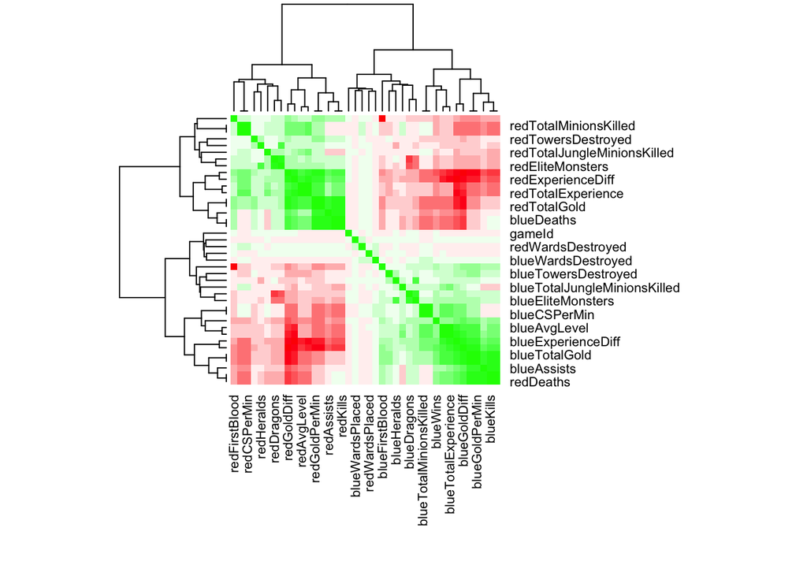

```r
res = cor(league_data)
heatmap(res, col = colorRampPalette(c("red", "white", "green"))(20), symm=TRUE, margins = c(10,10))
```

//Observation: Gives me a visual of the correlation between variables

# Finding correlation that causes the winning rate for team blue

# Create a new data set with selected columns

```r
blue_team <- league_data |>
  select(blueKills, blueTotalGold, blueWins, blueTowersDestroyed, blueTotalMinionsKilled, blueHeralds)
```

# Create a new column indicating win/loss status

```r
blue_team2 <- blue_team |>
  mutate(BWins = ifelse(blueWins > 0, "Win", "Loss"))
```

[Test: x > 18,000 Gold]

# Filter data to only include games with more than 18000 gold

# Analyze the effect of having more than 18000 gold on your chances of winning

```r
blue_team_wins <- blue_team2 |>
  filter(blueTotalGold > 18000)
```

# Summarize win/loss rate for games with more than 18000 gold

```r
more_than_18000 <- data.frame(winning_chance = sum(blue_team_wins$BWins == "Win") / nrow(blue_team_wins) * 100,
                              losing_chance = sum(blue_team_wins$BWins == "Loss") / nrow(blue_team_wins) * 100)
```

# Plot histogram of blueTotalGold for games with more than 18000 gold

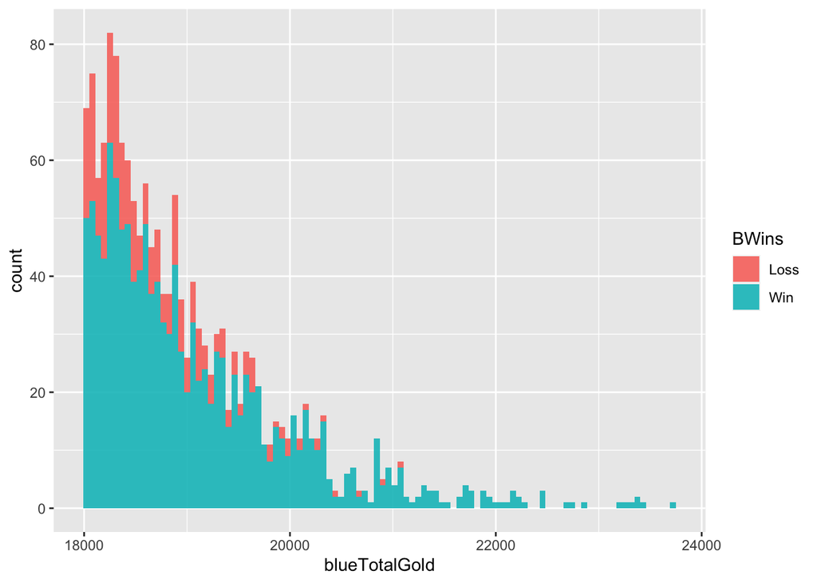

```r
ggplot(blue_team_wins) +
  geom_histogram(mapping = aes(x = blueTotalGold, fill = BWins), bins = 100, alpha = 0.9)
```

//Observation: Having over 18000 gold gives you an 81% likelihood of winning the game and a 18% likelihood of losing it.

[Test: x < 16,000 Gold]

# Filter data to only include games with less than 16000 gold

```r
blue_team_downward_linear <- blue_team2 |>
  filter(blueTotalGold < 16000)
```

# Summarize win/loss rate for games with less than 16000 gold

```r
less_than_16000 <- data.frame(losing_chance = sum(blue_team_downward_linear$BWins == "Loss") / nrow(blue_team_downward_linear) * 100,
                              winning_chance = sum(blue_team_downward_linear$BWins == "Win") / nrow(blue_team_downward_linear) * 100)
```

# Plot histogram of blueTotalGold for games with less than 16000 gold

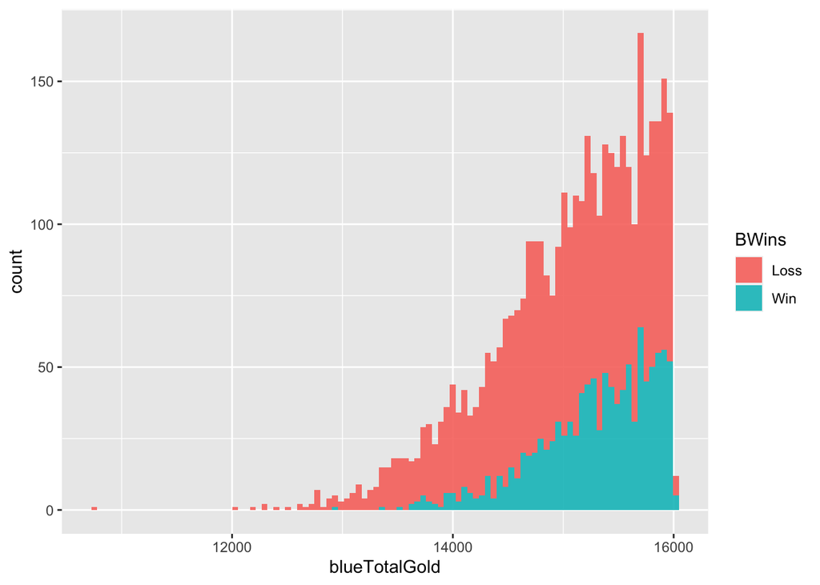

```r
ggplot(blue_team_downward_linear) +
  geom_histogram(mapping = aes(x = blueTotalGold, fill = BWins), bins = 100, alpha = 0.9)
```

[Test: Minion and Gold Correlation]

# MORE gold from minions analysis

# Create new data set with selected columns

```r
minions_gold <- league_data |>
  select(blueTotalGold, blueTotalMinionsKilled, blueWins)
```

# Filter data to only include games with more than 18000 gold

```r
minions_gold_v2 <- minions_gold |>
  filter(blueTotalGold > 18000)
```

# Plot results

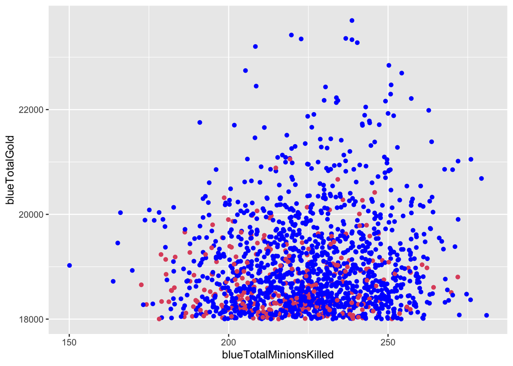

```r
ggplot(data = minions_gold_v2) + geom_jitter(aes(x = blueTotalMinionsKilled, y = blueTotalGold, color = blueWins), show.legend = FALSE) + scale_color_gradient("Wins", low = "10", high = "blue")
```

[Test: tower’s Destroyed 0]